# HW5_Sonam

Sonam Rathod

2024-10-10

```r
library(forecast)
library(tidyverse)
```

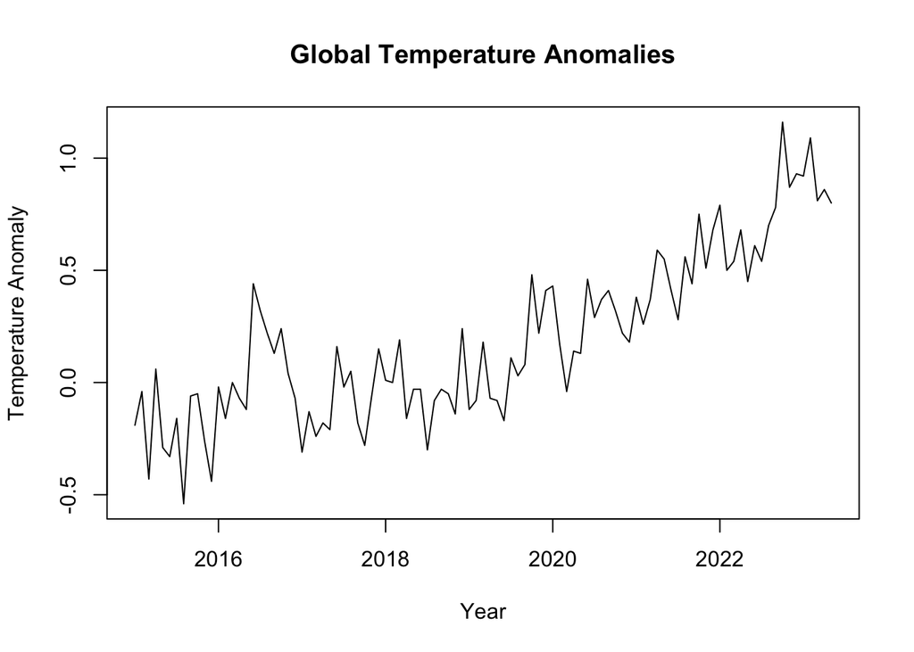

```r
library(lubridate)
global_temps <- read.csv("~/Downloads/archive/global_temps.csv")

global_temps_ts <- global_temps %>%
  gather(key = "Month", value = "Temperature", Jan:Dec) %>%
  mutate(Year = as.Date(paste(Year, match(Month, month.abb), "1", sep = "-"))) %>%
  select(Year, Temperature)
global_temps_ts <- na.omit(global_temps_ts)

# Create the time series object
temperature_ts <- ts(global_temps_ts$Temperature, start = 1880, end = c(2023,5) ,frequency = 12)

temperature_window_ts <- window(temperature_ts, start = c(2015, 1), end = c(2023, 5))

# Plot the zoomed-in time series
plot(temperature_window_ts, main = "Global Temperature Anomalies", ylab = "Temperature Anomaly", xlab = "Year")
```

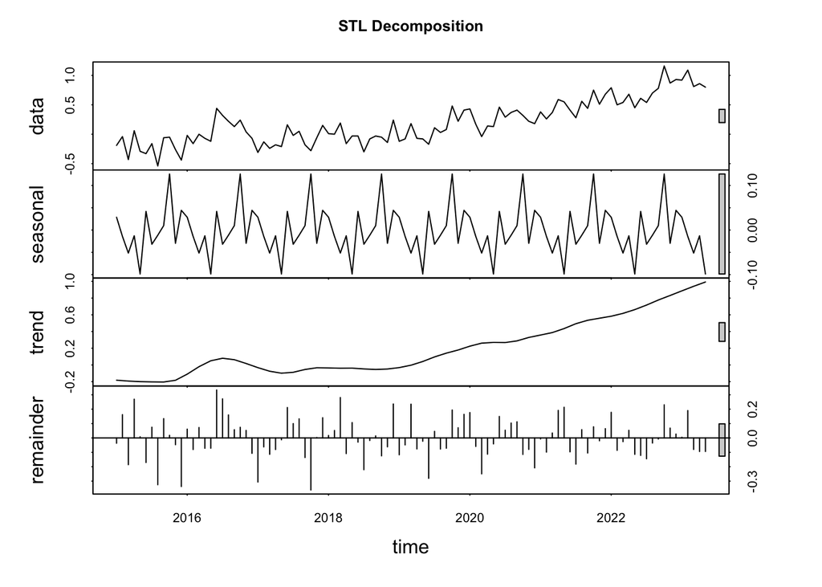

```r
# Perform STL decomposition on time series
stl_decomp_window <- stl(temperature_window_ts, s.window = "periodic")

# Plot the zoomed-in STL decomposition results
plot(stl_decomp_window, main = "STL Decomposition")
```

##### The decomposition separates the data into four components: data, seasonal, trend, and remainder.

1. The data shows a clear rising trend in recent years, indicating warming temperatures.
2. The seasonal component is stable, confirming regular yearly patterns.
3. The remainders are mostly noise, implying the unexplained variability after accounting for the trend and seasonality.

```r
attributes(stl_decomp_window)
```

```
## $names
## [1] "time.series" "weights"     "call"        "win"         "deg"
## [6] "jump"        "inner"       "outer"
##
## $class
## [1] "stl"
```

```r
summary(stl_decomp_window)
```

```
##  Call:
##  stl(x = temperature_window_ts, s.window = "periodic")
##
##  Time.series components:
##     seasonal               trend              remainder
##  Min.   :-0.09859474   Min.   :-0.2041482   Min.   :-0.3618990
##  1st Qu.:-0.03187920   1st Qu.:-0.0486386   1st Qu.:-0.0940878
##  Median :-0.01287734   Median : 0.0649915   Median :-0.0127703
##  Mean   :-0.00147125   Mean   : 0.1961760   Mean   :-0.0019325
##  3rd Qu.: 0.02870622   3rd Qu.: 0.4114531   3rd Qu.: 0.0774034
##  Max.   : 0.12575959   Max.   : 0.9926454   Max.   : 0.3332120
##  IQR:
##      STL.seasonal STL.trend STL.remainder data
##      0.06059      0.46009   0.17149       0.51000
##    %  11.9         90.2      33.6         100.0
##
##  Weights: all == 1
##
##  Other components: List of 5
##  $ win  : Named num [1:3] 1011 19 13
##  $ deg  : Named int [1:3] 0 1 1
##  $ jump : Named num [1:3] 102 2 2
##  $ inner: int 2
##  $ outer: int 0
```

#### IQR Values

- STL.seasonal (0.06059) - It is relatively small compared to the trend, indicating that the seasonal variations in the data have limited magnitude.
- STL.trend (0.46009) - It is the largest, suggesting that the long-term changes in the temperature anomalies account for a significant portion of the total variability.
- STL.remainder (0.17149) - The component shows some variability, indicating that there are still random fluctuations or noise not captured by the trend or seasonal components.
- data (0.51000) - The IQR for the original data represents the total spread of the middle 50% of the values in the time series.

```r
# Lets print out a seasonal adjustment
seasadj(stl_decomp_window)
```

```
##              Jan         Feb         Mar         Apr         May         Jun
## 2015 -0.21870622 -0.02577316 -0.37839598  0.07287734 -0.19140526 -0.37179655
## 2016 -0.04870622 -0.14577316  0.05160402 -0.05712266 -0.02140526  0.39820345
## 2017 -0.33870622 -0.11577316 -0.18839598 -0.16712266 -0.11140526  0.11820345
## 2018 -0.01870622  0.01422684  0.24160402 -0.14712266  0.06859474 -0.07179655
## 2019 -0.14870622 -0.06577316  0.23160402 -0.05712266  0.01859474 -0.21179655
## 2020  0.40129378  0.18422684  0.01160402  0.15287734  0.22859474  0.41820345
## 2021  0.35129378  0.27422684  0.42160402  0.60287734  0.64859474  0.36820345
## 2022  0.76129378  0.51422684  0.59160402  0.69287734  0.54859474  0.56820345
## 2023  0.89129378  1.10422684  0.86160402  0.87287734  0.89859474
##              Jul         Aug         Sep         Oct         Nov         Dec
## 2015 -0.12812080 -0.52839862 -0.06992624 -0.17575959 -0.23034306 -0.48425188
## 2016  0.35187920  0.23160138  0.12007376  0.11424041  0.06965694 -0.11425188
## 2017  0.01187920  0.06160138 -0.18992624 -0.40575959 -0.03034306  0.10574812
## 2018 -0.26812080 -0.06839862 -0.03992624 -0.17575959 -0.11034306  0.19574812
## 2019  0.14187920  0.04160138  0.07007376  0.35424041  0.24965694  0.36574812
## 2020  0.32187920  0.38160138  0.40007376  0.19424041  0.24965694  0.13574812
## 2021  0.31187920  0.57160138  0.43007376  0.62424041  0.53965694  0.63574812
## 2022  0.57187920  0.71160138  0.77007376  1.03424041  0.89965694  0.88574812
## 2023
```

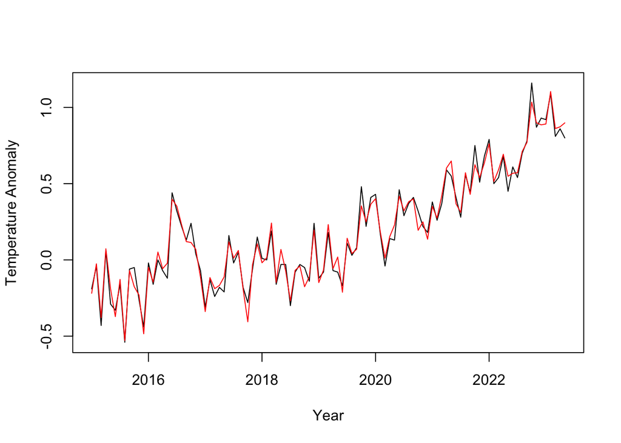

```r
# Plot a line on the graph
plot(temperature_window_ts,ylab = "Temperature Anomaly", xlab = "Year")

lines(seasadj(stl_decomp_window), col="Red")
```

The black line shows both the long-term trend and repeating seasonal patterns. You can see these seasonal changes as small ups and downs on top of the overall direction of the line.

The red line represents the data after taking out the seasonal changes. This makes it easier to see the true trend without the seasonal ups and downs.

The fact that the red line is going up over time shows a clear increase in temperatures, suggesting that global temperatures are rising.

```r
forecast_stl <- forecast(stl_decomp_window)

forecast_stl <- forecast(stl_decomp_window,h=15)
forecast_stl
```

```
##          Point Forecast     Lo 80    Hi 80     Lo 95    Hi 95
## Jun 2023      0.9437407 0.7241662 1.163315 0.6079304 1.279551
## Jul 2023      0.8700650 0.6322874 1.107843 0.5064156 1.233714
## Aug 2023      0.8903428 0.6356600 1.145026 0.5008391 1.279847
## Sep 2023      0.9118704 0.6413367 1.182404 0.4981248 1.325616
## Oct 2023      1.0277038 0.7421978 1.313210 0.5910601 1.464347
## Nov 2023      0.8722873 0.5725560 1.172019 0.4138878 1.330687
## Dec 2023      0.9461961 0.6328847 1.259507 0.4670277 1.425364
## Jan 2024      0.9306504 0.6043236 1.256977 0.4315767 1.429724
## Feb 2024      0.8877174 0.5488747 1.226560 0.3695023 1.405932
## Mar 2024      0.8503402 0.4994278 1.201253 0.3136660 1.387014
## Apr 2024      0.8890669 0.5264863 1.251647 0.3345477 1.443586
## May 2024      0.8033495 0.4294647 1.177234 0.2315420 1.375157
## Jun 2024      0.9437407 0.5588836 1.328598 0.3551526 1.532329
## Jul 2024      0.8700650 0.4745398 1.265590 0.2651614 1.474969
## Aug 2024      0.8903428 0.4844299 1.296256 0.2695525 1.511133
```

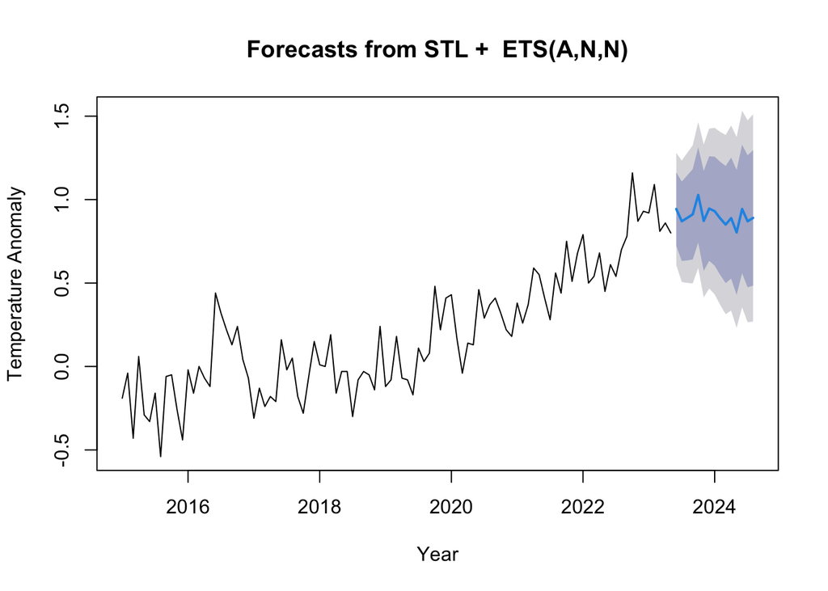

```r
plot(forecast_stl,ylab = "Temperature Anomaly", xlab = "Year")
```

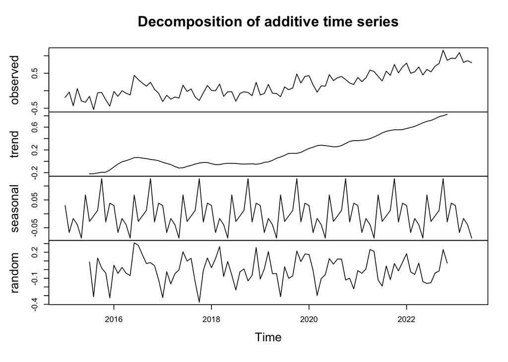

```r
decomposition <- decompose(temperature_window_ts)
plot(decomposition)
```

The trend component clearly shows an upward trajectory, consistent with increasing global temperatures. The seasonal component remains relatively stable, indicating regular fluctuations without significant changes over time.

```r
print(decomposition$type)
```

```
## [1] "additive"
```

```r
# Each one shows different attributes
attributes(decomposition)
```

```
## $names
## [1] "x"        "seasonal" "trend"    "random"   "figure"   "type"
##
## $class
## [1] "decomposed.ts"
```

```r
seasadj(decomposition)
```

```
##               Jan          Feb          Mar          Apr          May
## 2015 -0.219912574  0.027349330 -0.413126860  0.099075521 -0.202710193
## 2016 -0.049912574 -0.092650670  0.016873140 -0.030924479 -0.032710193
## 2017 -0.339912574 -0.062650670 -0.223126860 -0.140924479 -0.122710193
## 2018 -0.019912574  0.067349330  0.206873140 -0.120924479  0.057289807
## 2019 -0.149912574 -0.012650670  0.196873140 -0.030924479  0.007289807
## 2020  0.400087426  0.237349330 -0.023126860  0.179075521  0.217289807
## 2021  0.350087426  0.327349330  0.386873140  0.629075521  0.637289807
## 2022  0.760087426  0.567349330  0.556873140  0.719075521  0.537289807
## 2023  0.890087426  1.157349330  0.826873140  0.899075521  0.887289807
##               Jun          Jul          Aug          Sep          Oct
## 2015 -0.397829241 -0.132628348 -0.532211682 -0.072367932 -0.176742932
## 2016  0.372170759  0.347371652  0.227788318  0.117632068  0.113257068
## 2017  0.092170759  0.007371652  0.057788318 -0.192367932 -0.406742932
## 2018 -0.097829241 -0.272628348 -0.072211682 -0.042367932 -0.176742932
## 2019 -0.237829241  0.137371652  0.037788318  0.067632068  0.353257068
## 2020  0.392170759  0.317371652  0.377788318  0.397632068  0.193257068
## 2021  0.342170759  0.307371652  0.567788318  0.427632068  0.623257068
## 2022  0.542170759  0.567371652  0.707788318  0.767632068  1.033257068
## 2023
##               Nov          Dec
## 2015 -0.230649182 -0.478245908
## 2016  0.069350818 -0.108245908
## 2017 -0.030649182  0.111754092
## 2018 -0.110649182  0.201754092
## 2019  0.249350818  0.371754092
## 2020  0.249350818  0.141754092
## 2021  0.539350818  0.641754092
## 2022  0.899350818  0.891754092
## 2023
```

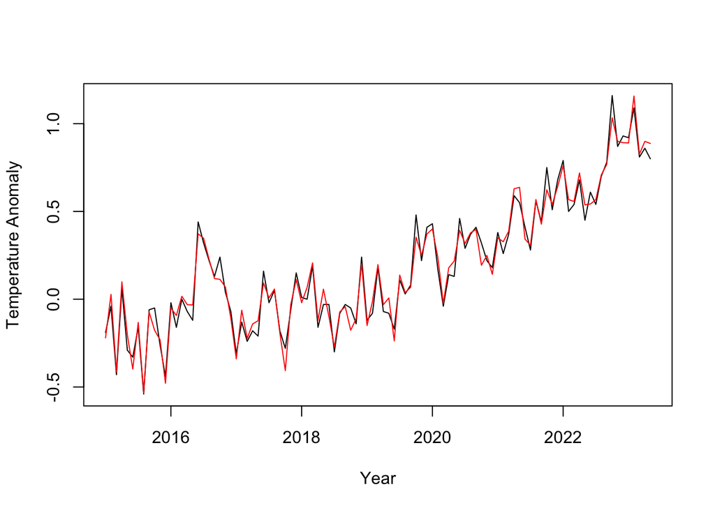

```r
plot(temperature_window_ts, ylab = "Temperature Anomaly", xlab = "Year")
lines(seasadj(decomposition), col="Red")
```

### Conclusion

The analysis highlights a clear upward trend in global temperatures with stable seasonal effects. The current forecast may not fully capture the continued warming trend, suggesting that more sophisticated models should be used for better predictions of future temperature changes.